# churn_analysis.rmd

2025-05-01

# 🛍️ What Drives Customer Loyalty? – An R-Based Behavioral Analysis

## 📌 Project Summary

This project explores customer behavior to identify key factors that influence loyalty and churn. Using R, I performed data cleaning, exploratory data analysis, predictive modeling, and business insight generation.

The goal is to provide actionable recommendations that help companies understand their customers better and reduce churn.

## 📁 Dataset

Source: [Kaggle – Telco Customer Churn](https://www.kaggle.com/datasets/blastchar/telco-customer-churn)

Size: ~7,000 entries  
Features: Customer demographics, service usage, account info, churn flag

## 🔍 Key Questions

- What customer features are most correlated with loyalty or churn?
- Can we predict churn based on customer traits?
- What actions might reduce churn?

## Data Overview

```r
data <- read.csv("~/Downloads/Telco-Customer-Churn.csv")
glimpse(data)
```

```
## Rows: 7,043
## Columns: 21
## $ customerID       <chr> "7590-VHVEG", "5575-GNVDE", "3668-QPYBK", "7795-CFOCW…
## $ gender           <chr> "Female", "Male", "Male", "Male", "Female", "Female",…
## $ SeniorCitizen    <int> 0, 0, 0, 0, 0, 0, 0, 0, 0, 0, 0, 0, 0, 0, 0, 0, 0, 0,…
## $ Partner          <chr> "Yes", "No", "No", "No", "No", "No", "No", "No", "Yes…
## $ Dependents       <chr> "No", "No", "No", "No", "No", "No", "Yes", "No", "No"…
## $ tenure           <int> 1, 34, 2, 45, 2, 8, 22, 10, 28, 62, 13, 16, 58, 49, 2…
## $ PhoneService     <chr> "No", "Yes", "Yes", "No", "Yes", "Yes", "Yes", "No", …
## $ MultipleLines    <chr> "No phone service", "No", "No", "No phone service", "…
## $ InternetService  <chr> "DSL", "DSL", "DSL", "DSL", "Fiber optic", "Fiber opt…
## $ OnlineSecurity   <chr> "No", "Yes", "Yes", "Yes", "No", "No", "No", "Yes", "…
## $ OnlineBackup     <chr> "Yes", "No", "Yes", "No", "No", "No", "Yes", "No", "N…
## $ DeviceProtection <chr> "No", "Yes", "No", "Yes", "No", "Yes", "No", "No", "Y…
## $ TechSupport      <chr> "No", "No", "No", "Yes", "No", "No", "No", "No", "Yes…
## $ StreamingTV      <chr> "No", "No", "No", "No", "No", "Yes", "Yes", "No", "Ye…
## $ StreamingMovies  <chr> "No", "No", "No", "No", "No", "Yes", "No", "No", "Yes…
## $ Contract         <chr> "Month-to-month", "One year", "Month-to-month", "One …
## $ PaperlessBilling <chr> "Yes", "No", "Yes", "No", "Yes", "Yes", "Yes", "No", …
## $ PaymentMethod    <chr> "Electronic check", "Mailed check", "Mailed check", "…
## $ MonthlyCharges   <dbl> 29.85, 56.95, 53.85, 42.30, 70.70, 99.65, 89.10, 29.7…
## $ TotalCharges     <dbl> 29.85, 1889.50, 108.15, 1840.75, 151.65, 820.50, 1949…
## $ Churn            <chr> "No", "No", "Yes", "No", "Yes", "Yes", "No", "No", "Y…
```

## Data Cleaning

```r
data <- data %>%
  clean_names() %>%
  drop_na()
```

## Exploratory Data Analysis

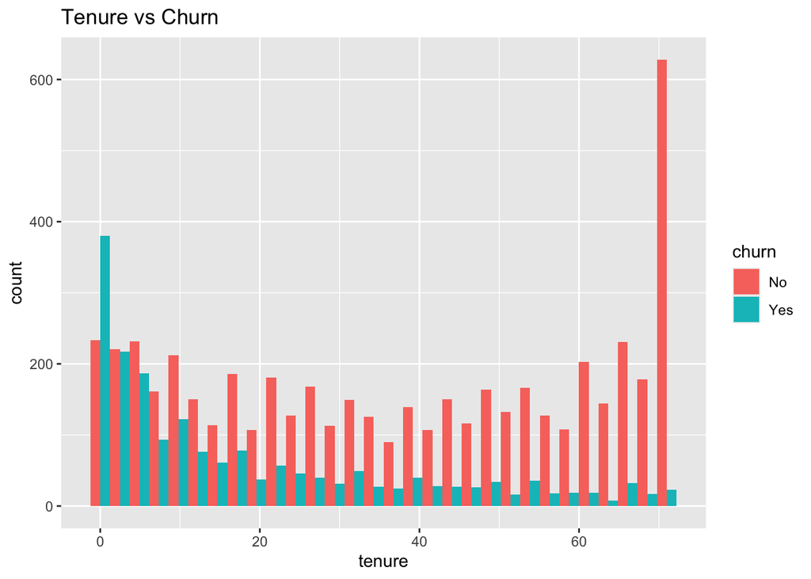

```r
ggplot(data, aes(x=tenure, fill=churn)) +
  geom_histogram(bins=30, position="dodge") +
  labs(title="Tenure vs Churn")
```

## Modeling - Logistic Regression

```r
# Convert churn to factor (if it's not already)
data$churn <- as.factor(data$churn)

# Check levels
levels(data$churn)
```

```
## [1] "No"  "Yes"
```

```r
# Logistic regression with a factor response
model <- glm(churn ~ tenure + contract + monthly_charges,
             data = data,
             family = "binomial")
summary(model)
```

```
##
## Call:
## glm(formula = churn ~ tenure + contract + monthly_charges, family = "binomial",
##     data = data)
##
## Coefficients:
##                   Estimate Std. Error z value Pr(>|z|)
## (Intercept)      -1.600590   0.089669  -17.85   <2e-16 ***
## tenure           -0.035931   0.002049  -17.53   <2e-16 ***
## contractOne year -1.057378   0.100627  -10.51   <2e-16 ***
## contractTwo year -1.993535   0.166946  -11.94   <2e-16 ***
## monthly_charges   0.028637   0.001350   21.22   <2e-16 ***
## ---
## Signif. codes:  0 '***' 0.001 '**' 0.01 '*' 0.05 '.' 0.1 ' ' 1
##
## (Dispersion parameter for binomial family taken to be 1)
##
##     Null deviance: 8143.4  on 7031  degrees of freedom
## Residual deviance: 6143.5  on 7027  degrees of freedom
## AIC: 6153.5
##
## Number of Fisher Scoring iterations: 6
```

## Results

My model predicts whether a customer is likely to churn based on their tenure, contract type, and monthly charges. All predictors are statistically significant (p < 0.001), meaning their influence on churn is not due to chance.

## 🔍 Coefficient-by-Coefficient Interpretation

### 1. Intercept = -1.6006

This is the baseline log-odds of churning for a customer with:

0 tenure,

a month-to-month contract,

$0 monthly charges.

Not directly interpretable alone, but it’s part of the full equation.

### 2. Tenure = -0.0359

Odds Ratio: exp(-0.0359) ≈ 0.965

🗣️ “Each additional month a customer stays decreases the odds of churning by about 3.5%.”

### 3. ContractOne year = -1.0574

Odds Ratio: exp(-1.0574) ≈ 0.347

🗣️ “Compared to month-to-month contracts, customers on a one-year contract are about 65% less likely to churn.”

### 4. ContractTwo year = -1.9935

Odds Ratio: exp(-1.9935) ≈ 0.136

🗣️ “Compared to month-to-month, two-year contract customers are 86% less likely to churn.”

### 5. Monthly Charges = +0.0286

Odds Ratio: exp(0.0286) ≈ 1.029

🗣️ “For every $1 increase in monthly charges, the odds of churn increase by about 2.9%.”

This could indicate pricing sensitivity or dissatisfaction with value for money.

📊 Model Fit Indicators Null Deviance: 8143.4 → model with no predictors

Residual Deviance: 6143.5 → model reduced deviance by ~2000

AIC = 6153.5 → lower is better; this is decent for this size dataset

Conclusion: model fits the data much better than a random guess.

## Conclusion

Our logistic regression model identified key predictors of customer churn:

Longer tenure significantly reduces churn risk (OR ≈ 0.965).

Customers on one-year or two-year contracts are 65–86% less likely to churn than those on month-to-month plans.

Higher monthly charges slightly increase churn likelihood, suggesting pricing may impact retention.

All predictors were highly significant (p < 0.001), and the model explained a substantial portion of deviance, suggesting strong explanatory power.

## Visualization Code

### 1. Effect of Tenure

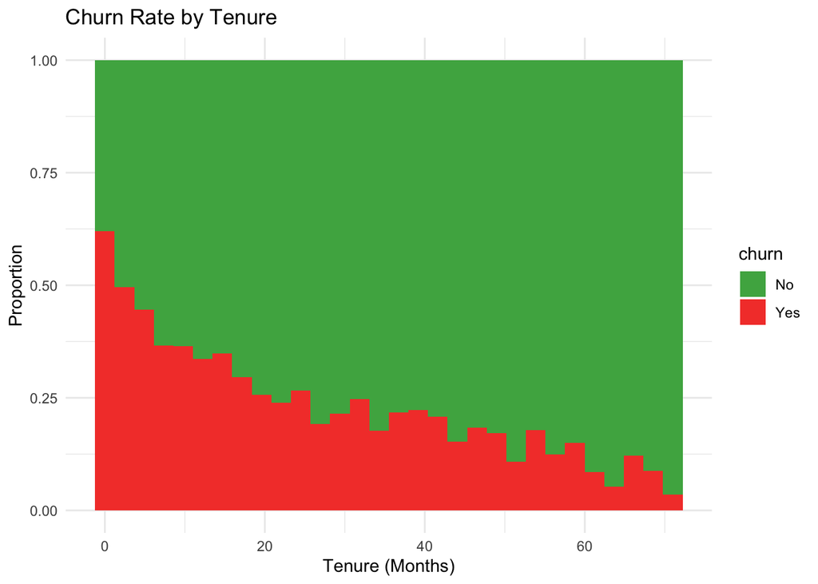

```r
ggplot(data, aes(x = tenure, fill = churn)) +
  geom_histogram(position = "fill", bins = 30) +
  labs(title = "Churn Rate by Tenure",
       y = "Proportion", x = "Tenure (Months)") +
  scale_fill_manual(values = c("No" = "#4CAF50", "Yes" = "#F44336")) +
  theme_minimal()
```

### 2. Churn Rate by Contract Type

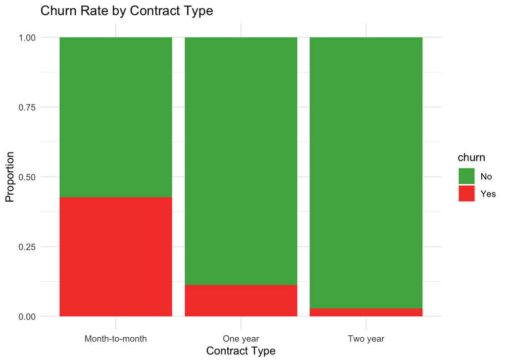

```r
ggplot(data, aes(x = contract, fill = churn)) +
  geom_bar(position = "fill") +
  labs(title = "Churn Rate by Contract Type",
       y = "Proportion", x = "Contract Type") +
  scale_fill_manual(values = c("No" = "#4CAF50", "Yes" = "#F44336")) +
  theme_minimal()
```

### 3. Effect of Monthly Charges

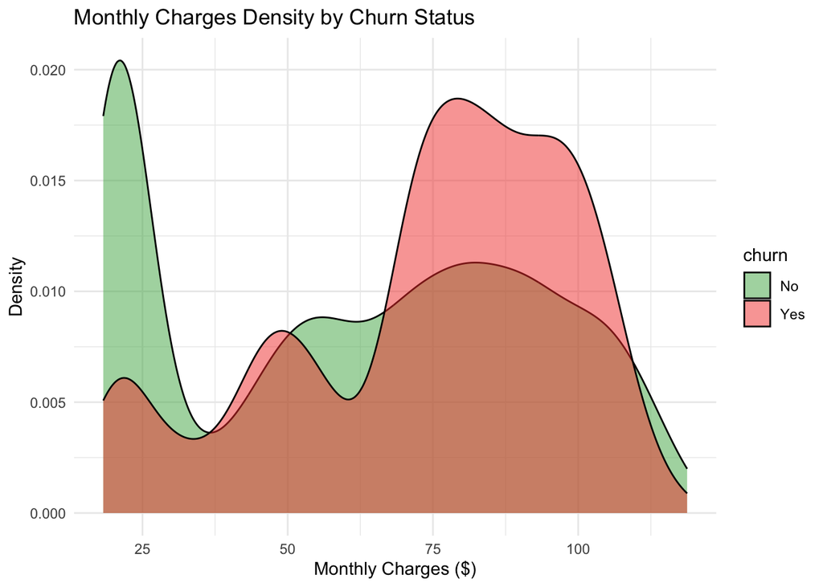

```r
ggplot(data, aes(x = monthly_charges, fill = churn)) +
  geom_density(alpha = 0.5) +
  labs(title = "Monthly Charges Density by Churn Status",
       x = "Monthly Charges ($)", y = "Density") +
  scale_fill_manual(values = c("No" = "#4CAF50", "Yes" = "#F44336")) +
  theme_minimal()
```

## 💼 Business Recommendations

Based on the analysis, the following actions are recommended to reduce churn:

1. **Incentivize Long-Term Contracts**
   - Promote one- and two-year contracts with attractive offers (e.g., discounts, loyalty points).
   - Consider auto-renewal features or early upgrade incentives to keep customers engaged.
2. **Target New Customers Early**
   - Since churn risk is higher during early tenure, create onboarding campaigns, exclusive new-user perks, or customer care follow-ups in the first 3–6 months.
3. **Review Pricing Strategy**
   - High monthly charges are linked to increased churn. Consider:
     - Bundling services to increase perceived value.
     - Tiered pricing with value-added services.
     - Monitoring competitor pricing closely.
4. **Churn Risk Scoring**
   - Use this model in a dashboard to proactively flag high-risk customers for personalized retention efforts (e.g., call center outreach, email offers).

By addressing these areas, the business can build stronger customer relationships, reduce revenue loss from churn, and improve long-term loyalty.